# BM_HW4

Coco Zou (xz2809)

11/9/2018

## Problem 1

### a

The Least Squares estimators of $\beta_{0}$ and $\beta_{1}$ are shown below:
$$\begin{aligned}
\hat{\beta_{0}} &= \bar{Y} - \hat{\beta_{1}}\bar{X}\\
\hat{\beta_{1}} &= \frac{\sum_{i=1}^{n} (X_{i} - \bar{X})(Y_{i} - \bar{Y})} {\sum_{i=1}^{n} (X_{i} - \bar{X})^2} \\
&= \frac{\sum_{i=1}^{n} X_{i}Y{i} - n\bar{X}\bar{Y}}{\sum_{i=1}^{n}X_{i}^2 - n\bar{X}^2}
\end{aligned}$$
To show they are unbiased estimators, we need to show $E(\hat{\beta}_{0}) = \beta_{0}$ and $E(\hat{\beta}_{1}) = \beta_{1}$

The derivation is shown below:
$$\begin{aligned}
E(\hat{\beta_{1}}) &= E(\frac{\sum_{i=1}^{n} (X_{i} - \bar{X})(Y_{i} - \bar{Y})} {\sum_{i=1}^{n} (X_{i} - \bar{X})^2}) \\
&= E(\frac{\sum_{i=1}^{n} (X_{i} - \bar{X})Y_{i} - \sum_{i=1}^{n} (X_{i} - \bar{X})\bar{Y}} {\sum_{i=1}^{n} (X_{i} - \bar{X})^2})\\
&= E(\frac{\sum_{i=1}^{n} (X_{i} - \bar{X})Y_{i}} {\sum_{i=1}^{n} (X_{i} - \bar{X})^2}) \\
&= E(\frac{\sum_{i=1}^{n} (X_{i} - \bar{X})(\beta_{0}+\beta_{1}X_{i}+\epsilon_{i})} {\sum_{i=1}^{n} (X_{i} - \bar{X})^2}) \\
&= E(\frac{\sum_{i=1}^{n} (X_{i} - \bar{X})(\beta_{1}X_{i})} {\sum_{i=1}^{n} (X_{i} - \bar{X})^2})\\
&=\beta_{1}E( \frac{\sum_{i=1}^{n} (X_{i} - \bar{X})(X_{i})} {\sum_{i=1}^{n} (X_{i} - \bar{X})X_{i} - \sum_{i=1}^{n} (X_{i} - \bar{X})\bar{X}}) \\
&= \beta_{1}E(\frac{\sum_{i=1}^{n} (X_{i} - \bar{X})(X_{i})} {\sum_{i=1}^{n} (X_{i} - \bar{X})X_{i}})\\
&= \beta_{1}
\end{aligned}$$

$$\begin{aligned}
E(\hat{\beta_{0}}) &= E(\bar{Y} - \hat{\beta_{1}}\bar{X}) \\
&=\bar{Y} - \bar{X}E(\hat{\beta_{1}})\\
&=\bar{Y} - \bar{X}\beta_{1}\\
&=\beta_{0}
\end{aligned}$$

### b

The Least Sqaure line equation is:
$$\hat{Y_{i} }= \hat{\beta_{0}} + \hat{\beta_{1}}X_{i}$$

We plug in the $\bar{X}$ into the equation and have:

$$\begin{aligned}
\hat{Y_{i} } &= \hat{\beta_{0}} + \hat{\beta_{1}}\bar{X} \\
&= \bar{Y} - \hat{\beta_{1}}\bar{X} + \hat{\beta_{1}}\bar{X} \\
&= \bar{Y}
\end{aligned}$$

Therefore, it always goes through the point $(\bar{X}, \bar{Y})$.

### c

The maximum likelihood method is shown below:
$$L(\beta_{0}, \beta_{1}, \sigma^2) = \prod_{i=1}^{n} \frac{1}{\sqrt{2\pi\sigma^2}}exp(-\frac{(Y_{i} - \beta_{0} - \beta_{1}X_{i})^2}{2\sigma^2})$$
We take the log transformation and then obtain:
$$ln L(\beta_{0}, \beta_{1}, \sigma^2) = -\frac{n}{2}log(2\pi) - nlog(\sigma)
-\frac{(Y_{i} - \beta_{0} - \beta_{1}X_{i})^2}{2\sigma^2}$$

Take derivative with respect to $\sigma$ and set to zero, we have:

$$\begin{align}
n\frac{1}{\sigma} - \frac{1}{\sigma^3}(Y_{i} - \beta_{0} - \beta_{1}X_{i})^2 = 0\\
\hat{\sigma^2} = \frac{1}{n}(Y_{i} - \beta_{0} - \beta_{1}X_{i})^2
\end{align}$$
The calculation of expected value of the $\hat{\sigma}^2$ is shown below:
$$\begin{align}
E(\hat{\sigma^2}) &= E( \frac{1}{n}(Y_{i} - \beta_{0} - \beta_{1}X_{i})^2)\\
&= \frac{1}{n}E((Y_{i} - \beta_{0} - \beta_{1}X_{i})^2)\\
&= \frac{1}{n}E((Y_{i} - \bar{Y})^2)\\
&= \frac{1}{n}*n*\sigma^2 \\
&= \sigma^2
\end{align}$$

## Problem 2

Here is the **code chunk** to load the data file

```r
heartdisease_df <- read_csv(file = "./data/HeartDisease.csv") %>%
  mutate(gender = as.numeric(gender))
```

### a

There are in total 788 observations and 10 variables. The main outcome is ‘total cost’. The main predictor is the ‘number of emergency room (ER) visits’, which is ‘ERvisits’ in the data set. The other important covariants including ‘age’, ‘gender’, ‘number of complications’ that arose during treatment, and ‘duration of treatment condition’, which in the data are indicated as ‘age’, ‘gender’, ‘complications’ and ‘duration’ repectively.

```r
summary(heartdisease_df$age)
```

```
##    Min. 1st Qu.  Median    Mean 3rd Qu.    Max.
##   24.00   55.00   60.00   58.72   64.00   70.00
```

```r
summary(heartdisease_df$duration)
```

```
##    Min. 1st Qu.  Median    Mean 3rd Qu.    Max.
##    0.00   41.75  165.50  164.03  281.00  372.00
```

Also, the number of male, indicated as 1, and the number of female, indicated as 0 are shown below:

```r
as.data.frame(table(heartdisease_df$gender))
```

```
##   Var1 Freq
## 1    0  608
## 2    1  180
```

### b

Investigate the shape of the distribution for variable ‘total cost’:

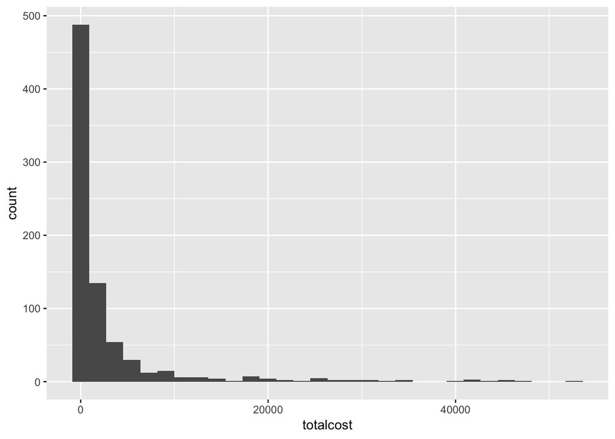

```r
heartdisease_df %>%
  ggplot(aes(x = totalcost))+geom_histogram()
```

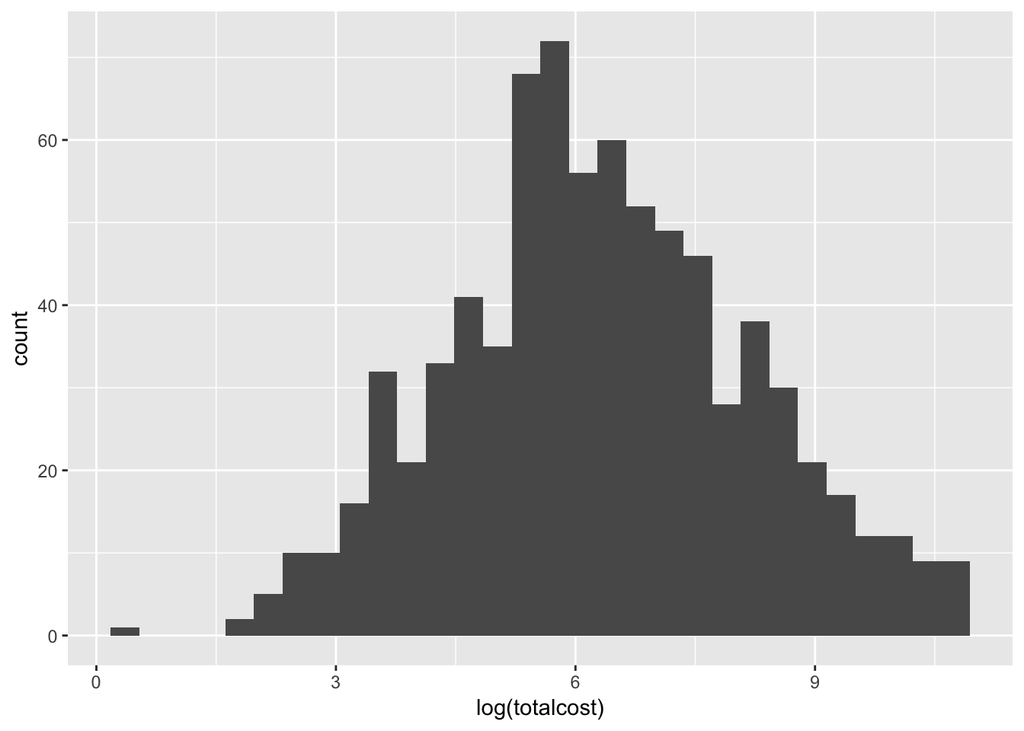

```r
heartdisease_df %>%
  ggplot(aes(x = log(totalcost)))+geom_histogram()
```

### c

Create a new variable called ‘comp_bin’ by dichotomizing ‘complications’: 0 if no complications, and 1 otherwise. The first five observations are shown below:

```r
heartdisease_df <- heartdisease_df %>%
  mutate(comp_bin = case_when(complications == 0 ~ 0,
                              TRUE ~ 1))
heartdisease_df %>%
  head(5) %>%
  knitr::kable(digits = 1)
```

| id | totalcost | age | gender | interventions | drugs | ERvisits | complications | comorbidities | duration | comp_bin |
| --- | --- | --- | --- | --- | --- | --- | --- | --- | --- | --- |
| 1 | 179.1 | 63 | 0 | 2 | 1 | 4 | 0 | 3 | 300 | 0 |
| 2 | 319.0 | 59 | 0 | 2 | 0 | 6 | 0 | 0 | 120 | 0 |
| 3 | 9310.7 | 62 | 0 | 17 | 0 | 2 | 0 | 5 | 353 | 0 |
| 4 | 280.9 | 60 | 1 | 9 | 0 | 7 | 0 | 2 | 332 | 0 |
| 5 | 18727.1 | 55 | 0 | 5 | 2 | 7 | 0 | 0 | 18 | 0 |

### d

Fit a simple linear regression (SLR) between the original or transformed ‘total cost’ and predictor ‘ERvisits’.

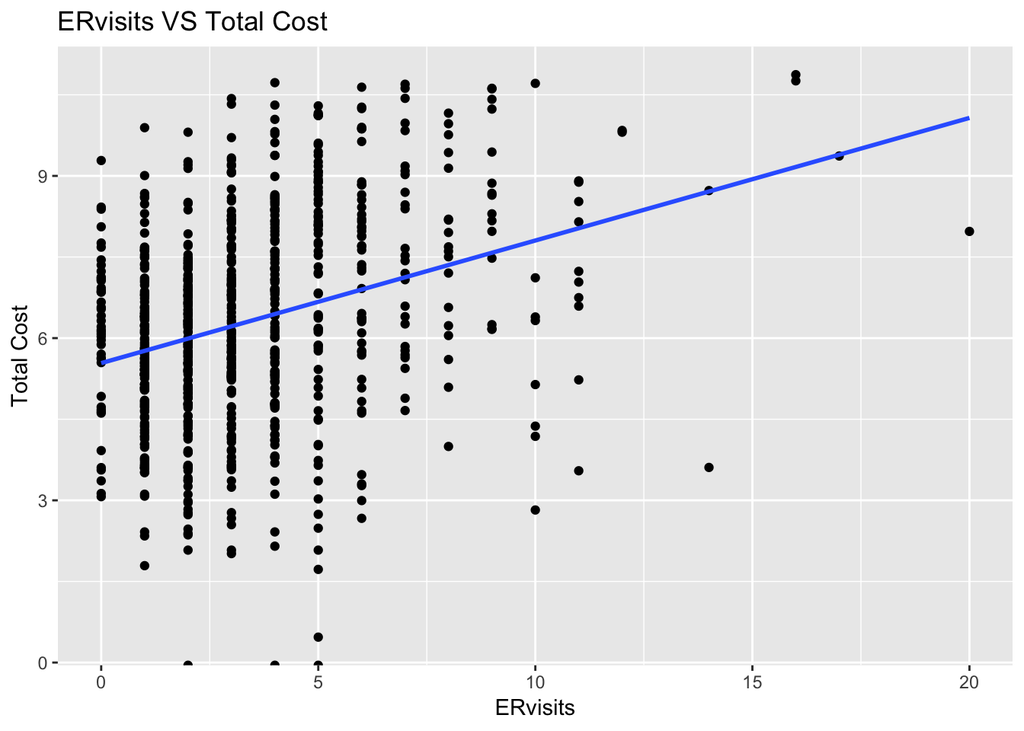

```r
p <-ggplot(heartdisease_df, aes(x = ERvisits, y = log(totalcost)))+geom_point()+
  geom_smooth(method = "lm", se = FALSE)+
  labs(
    title = "ERvisits VS Total Cost",
    x = "ERvisits",
    y = "Total Cost"
  )
p
```

```r
heartdisease_df <- heartdisease_df %>%
  mutate(logtotalcost = log(totalcost)) %>%
  filter(logtotalcost != -Inf)

simreg_result<- lm(logtotalcost~ ERvisits, data = heartdisease_df)
summary(simreg_result)
```

```
##
## Call:
## lm(formula = logtotalcost ~ ERvisits, data = heartdisease_df)
##
## Residuals:
##     Min      1Q  Median      3Q     Max
## -6.2013 -1.1265  0.0191  1.2668  4.2797
##
## Coefficients:
##             Estimate Std. Error t value Pr(>|t|)
## (Intercept)  5.53771    0.10362   53.44   <2e-16 ***
## ERvisits     0.22672    0.02397    9.46   <2e-16 ***
## ---
## Signif. codes:  0 '***' 0.001 '**' 0.01 '*' 0.05 '.' 0.1 ' ' 1
##
## Residual standard error: 1.772 on 783 degrees of freedom
## Multiple R-squared:  0.1026, Adjusted R-squared:  0.1014
## F-statistic:  89.5 on 1 and 783 DF,  p-value: < 2.2e-16
```

As we can see from the results above, for one unit of ERvisit change, we estimate there is 1.2544786 change in total cost. The p-value is extremely small, which means that the ER visits is significant to the change of total cost.

### e

#### i

Test if ‘comp_bin’ is an effect modifier of the relationship between ‘total cost’ and ‘ERvisits’.

```r
mulreg_result_21<- lm(logtotalcost~ ERvisits*comp_bin, data = heartdisease_df)
summary(mulreg_result_21) %>%
  broom::tidy()
```

```
## # A tibble: 4 x 5
##   term              estimate std.error statistic   p.value
##   <chr>                <dbl>     <dbl>     <dbl>     <dbl>
## 1 (Intercept)         5.50      0.103      53.1  1.36e-261
## 2 ERvisits            0.211     0.0245      8.61 3.99e- 17
## 3 comp_bin            2.18      0.546       3.99 7.17e-  5
## 4 ERvisits:comp_bin  -0.0993    0.0948     -1.05 2.96e-  1
```

The linear relationship between total coast and ERvisits and comp_bin is shown below:
$$TC = 5.50 + 0.211*ER + 2.18*compbin - 0.0992*ER*compbin$$
Since the p-value is 0.296, larger than 0.05. This means that we fail to reject the null hypothesis and conclude that comp_bin is not a effect modifier.

### e

#### 2

```r
mulreg_result_22<- lm(logtotalcost~ ERvisits + comp_bin, data = heartdisease_df)
summary(mulreg_result_22) %>%
  broom::tidy()
```

```
## # A tibble: 3 x 5
##   term        estimate std.error statistic   p.value
##   <chr>          <dbl>     <dbl>     <dbl>     <dbl>
## 1 (Intercept)    5.52     0.101      54.5  1.68e-268
## 2 ERvisits       0.205    0.0237      8.63 3.33e- 17
## 3 comp_bin       1.69     0.275       6.13 1.38e-  9
```

The linear relationship between total coast and ERvisits and comp_bin is shown below:
$$TC = 5.52 + 0.205*ER + 1.69*compbin$$
Then we calculate the percentage change in the parameter estimate and determine whether confounding is present:
$$\left\lvert{\frac{\beta_{crude} - \beta_{adjusted}}{\beta_{crude}}} \right\rvert= \left\rvert\frac{exp(0.2046) - exp(0.2267)}{exp(0.2046)}\right\rvert = 0.022$$
Since the percentage change is 2.2%, which is less than 10%, this indicates that the association between total cost and ERvisit is not confounded by comp_bin.

### e

#### 3

Since comp_bin is neither a effect modifier nor a counfounder, so ‘comp_bin’should not be included along with ’ERvisits’.

### f

#### i

```r
mulreg_result_23<- lm(logtotalcost~ ERvisits + age + gender + duration, data = heartdisease_df)
summary(mulreg_result_23)
```

```
##
## Call:
## lm(formula = logtotalcost ~ ERvisits + age + gender + duration,
##     data = heartdisease_df)
##
## Residuals:
##     Min      1Q  Median      3Q     Max
## -5.3012 -1.0790 -0.1215  1.0567  4.2854
##
## Coefficients:
##               Estimate Std. Error t value Pr(>|t|)
## (Intercept)  6.1967450  0.5162986  12.002  < 2e-16 ***
## ERvisits     0.1946147  0.0225477   8.631  < 2e-16 ***
## age         -0.0249155  0.0087695  -2.841  0.00461 **
## gender      -0.1189335  0.1408787  -0.844  0.39880
## duration     0.0057155  0.0004941  11.569  < 2e-16 ***
## ---
## Signif. codes:  0 '***' 0.001 '**' 0.01 '*' 0.05 '.' 0.1 ' ' 1
##
## Residual standard error: 1.639 on 780 degrees of freedom
## Multiple R-squared:  0.2359, Adjusted R-squared:  0.232
## F-statistic:  60.2 on 4 and 780 DF,  p-value: < 2.2e-16
```

The linear relationship between total coast and ERvisits, age, gender and duration is shown below:

$$TC = 6.20 + 0.195*ER - 0.02age - 0.12gender + 0.006 duration$$
The adjusted R-squared is 0.232, which means that it is not a very good linear regression.

### f

#### ii

To compare the SLR and MLR models, we need to perform partial ANOVA test. The null hypothesis $H_{0}: \beta{2} = \beta_{3} = \beta_{4} = 0$ The alternative hypothesis $H_{1}: \beta{2} \neq 0$ OR $\beta_{3} \neq 0$ OR $\beta_{4} \neq 0$

```r
anova(simreg_result,mulreg_result_23) %>%
  broom::tidy()
```

```
## # A tibble: 2 x 6
##   res.df   rss    df sumsq statistic   p.value
## *  <dbl> <dbl> <dbl> <dbl>     <dbl>     <dbl>
## 1    783 2460.    NA   NA       NA   NA
## 2    780 2094.     3  365.      45.4  4.98e-27
```

From the anova test above, since the p-value is extremly small, we could reject the null hypothesis and larger model is prefered. I would use the MLR model to address the investigator’s objective.

## Problem 3

```r
patsat_df<-read_csv(file = "./data/PatSatisfaction.csv") %>%
  janitor::clean_names()
```

### a

The correlation matrix is shown below:

```r
round(cor(patsat_df),3) %>%
  knitr::kable(digits = 2)
```

|  | safisfaction | age | severity | anxiety |
| --- | --- | --- | --- | --- |
| safisfaction | 1.00 | -0.79 | -0.60 | -0.64 |
| age | -0.79 | 1.00 | 0.57 | 0.57 |
| severity | -0.60 | 0.57 | 1.00 | 0.67 |
| anxiety | -0.64 | 0.57 | 0.67 | 1.00 |

### b

Fit a multiple regression model:

```r
mulreg_result_31 <- lm(safisfaction ~ age + severity + anxiety, data = patsat_df)
summary(mulreg_result_31)
```

```
##
## Call:
## lm(formula = safisfaction ~ age + severity + anxiety, data = patsat_df)
##
## Residuals:
##      Min       1Q   Median       3Q      Max
## -18.3524  -6.4230   0.5196   8.3715  17.1601
##
## Coefficients:
##             Estimate Std. Error t value Pr(>|t|)
## (Intercept) 158.4913    18.1259   8.744 5.26e-11 ***
## age          -1.1416     0.2148  -5.315 3.81e-06 ***
## severity     -0.4420     0.4920  -0.898   0.3741
## anxiety     -13.4702     7.0997  -1.897   0.0647 .
## ---
## Signif. codes:  0 '***' 0.001 '**' 0.01 '*' 0.05 '.' 0.1 ' ' 1
##
## Residual standard error: 10.06 on 42 degrees of freedom
## Multiple R-squared:  0.6822, Adjusted R-squared:  0.6595
## F-statistic: 30.05 on 3 and 42 DF,  p-value: 1.542e-10
```

```r
qf(0.95,3,42)
```

```
## [1] 2.827049
```

Decision rules: If test statistics $F* > F(1-\alpha;p,n-p-1) = F(0.95;3,46-3-1)$, reject $H_{0}$, If test statistics $F* \leqslant F(1-\alpha;p,n-p-1) = F(0.95;3,46-3-1)$, Fail to reject$H_{0}$

Conclusion: From the test above, we can see that p-value is extremely small and F-statistics is larger than $F(0.95;3,46-3-1)$, therefore, we could reject $H_{0}$ and conclude that there at least one of the $\beta$ is not zero, there is a regression relation between safisfaction and age + severity + anxiety.

### c

Show the regression results for all estimated coefficients with 95% CIs.

```r
summary(mulreg_result_31)
```

```
##
## Call:
## lm(formula = safisfaction ~ age + severity + anxiety, data = patsat_df)
##
## Residuals:
##      Min       1Q   Median       3Q      Max
## -18.3524  -6.4230   0.5196   8.3715  17.1601
##
## Coefficients:
##             Estimate Std. Error t value Pr(>|t|)
## (Intercept) 158.4913    18.1259   8.744 5.26e-11 ***
## age          -1.1416     0.2148  -5.315 3.81e-06 ***
## severity     -0.4420     0.4920  -0.898   0.3741
## anxiety     -13.4702     7.0997  -1.897   0.0647 .
## ---
## Signif. codes:  0 '***' 0.001 '**' 0.01 '*' 0.05 '.' 0.1 ' ' 1
##
## Residual standard error: 10.06 on 42 degrees of freedom
## Multiple R-squared:  0.6822, Adjusted R-squared:  0.6595
## F-statistic: 30.05 on 3 and 42 DF,  p-value: 1.542e-10
```

```r
confint(mulreg_result_31,level=0.95)
```

```
##                  2.5 %      97.5 %
## (Intercept) 121.911727 195.0707761
## age          -1.575093  -0.7081303
## severity     -1.434831   0.5508228
## anxiety     -27.797859   0.8575324
```

For every unit change in severity of illness, the change in the satisfaction is approximately -0.44. We are 95% confident that the change in the satisfaction would fall into the range (-1.43,0.55).

### d

Obtain an interval estimate for a new patient’s satisfaction when Age=35, Severity=42, Anxiety=2.1.

```r
predict(mulreg_result_31,data.frame(age = 35, severity = 42, anxiety = 2.1),interval="confidence")
```

```
##        fit      lwr      upr
## 1 71.68332 64.23592 79.13071
```

The satisfaction of the new patient is approximately 71.68 according to the model. We are 95% confident of the satisfaction of the new patient would fall into the range (64.24, 79.13).

### e

Test whether ‘anxiety level’ can be dropped from the regression model, given the other two covariates are retained.

```r
mulreg_result_3 <- lm(safisfaction ~ age + severity, data = patsat_df)
mulreg_result_4<- lm(safisfaction ~ age + severity + anxiety , data = patsat_df)
anova(mulreg_result_3,mulreg_result_4)
```

```
## Analysis of Variance Table
##
## Model 1: safisfaction ~ age + severity
## Model 2: safisfaction ~ age + severity + anxiety
##   Res.Df    RSS Df Sum of Sq      F  Pr(>F)
## 1     43 4613.0
## 2     42 4248.8  1    364.16 3.5997 0.06468 .
## ---
## Signif. codes:  0 '***' 0.001 '**' 0.01 '*' 0.05 '.' 0.1 ' ' 1
```

```r
qf(p =0.05, df1 = 1, df2 = 46-3-1)
```

```
## [1] 0.003979415
```

Decision rules: If test statistics $F* > F(1-\alpha;dfL-dfS,dfL) = F(0.95;1,46-3-1)$, reject $H_{0}$, If test statistics $F* \leqslant F(1-\alpha;p,n-p-1) = F(0.95;1,46-3-1)$, Fail to reject$H_{0}$